# American Soldier - Initial Analysis

Morgan Stockham

6/23/2020

# Topic Modeling

## Average Responses

The average responses for black soldiers and white soldiers on questions 77 and 78 are a small size for LDA analysis. The average response for black soldiers for their thoughts on the survey is about 70 words. The average for white soldiers on the short response is 7 and the average for their thoughts on the entire survey are about 47 words. Therefore, analysis using Topic Modelling will be less powerful than other methods.

```r
summary(n_words$n)
```

```
##    Min. 1st Qu.  Median    Mean 3rd Qu.    Max.
##    1.00   29.00   58.00   70.46  105.00  343.00
```

```r
summary(words_77$n)
```

```
##    Min. 1st Qu.  Median    Mean 3rd Qu.    Max.
##   1.000   1.000   5.000   7.179  11.000 153.000
```

```r
summary(words_78$n)
```

```
##    Min. 1st Qu.  Median    Mean 3rd Qu.    Max.
##    1.00   15.00   36.00   47.65   74.00  235.00
```

## Topic Modelling Graphs

From these graphs we can see that there is a lot of overlap in topics across the three questions and two groups. The following graphs show the density of topics within three clusters of topics across each group and question. There is quite a bit of overlap between them because of the short responses.

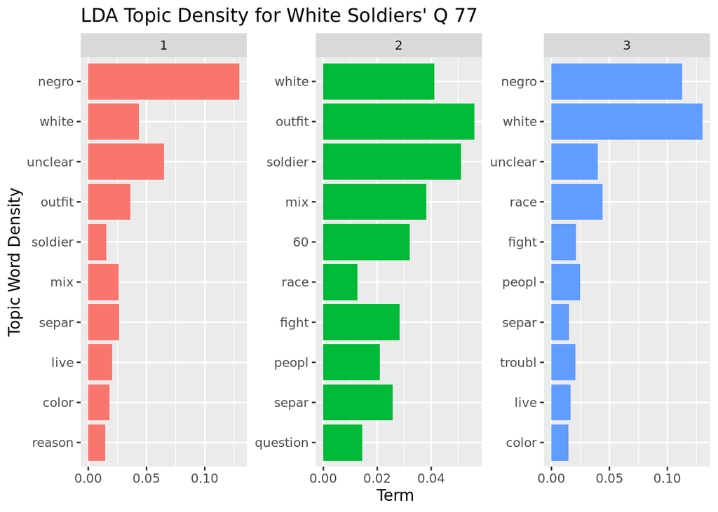

[figure not shown]

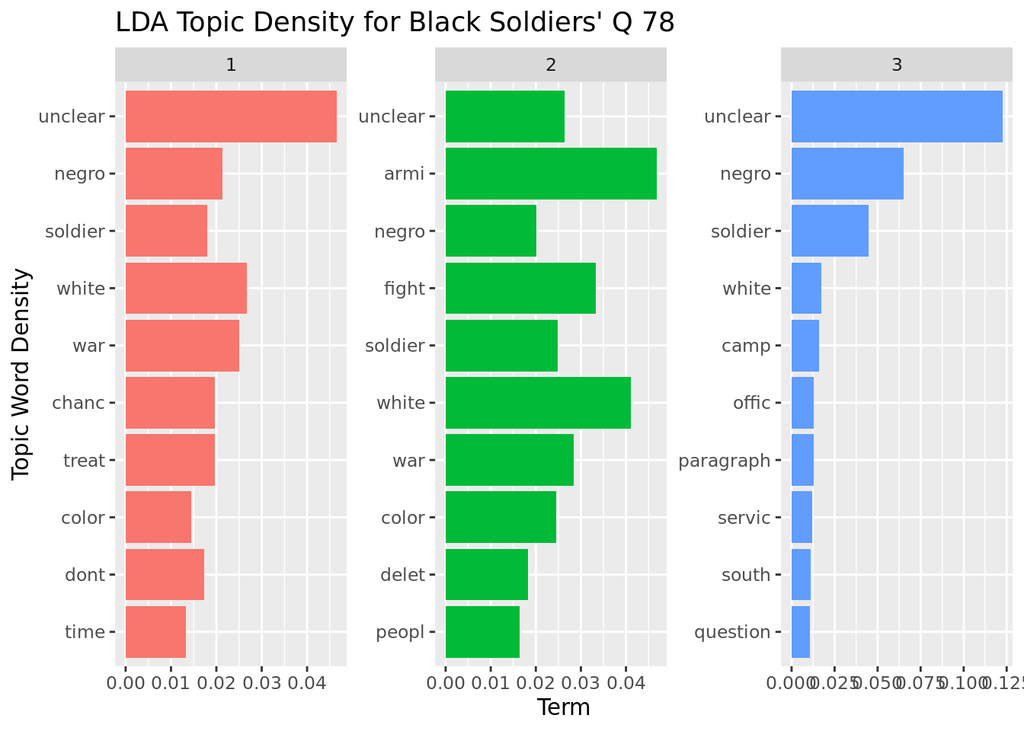

## Euclidean Distance Measures

Through the production of a euclidean distance measure we can see the difference between white and black soldiers is $.122$. This determines that the difference between topics of black soldiers and white soldiers for their thoughts on the entire survey is small.

```
## [1] 0.1220998
```

# Sentiment Analysis

## Differences in Sentiment Libraries

We have created plots for the sentiments by person's reponse across each sentiment library. The three we include in this initial analysis are the AFINN, Bing, and NRC libraries. Each individual vertical line represents the total sentiment of one soldier.

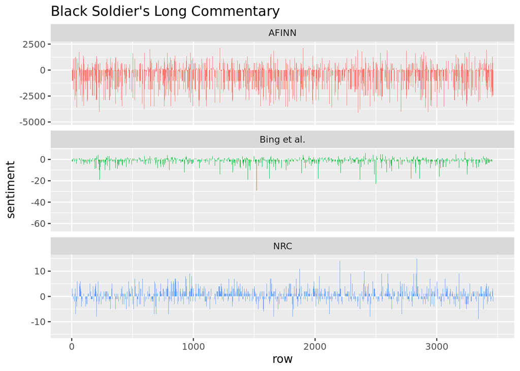

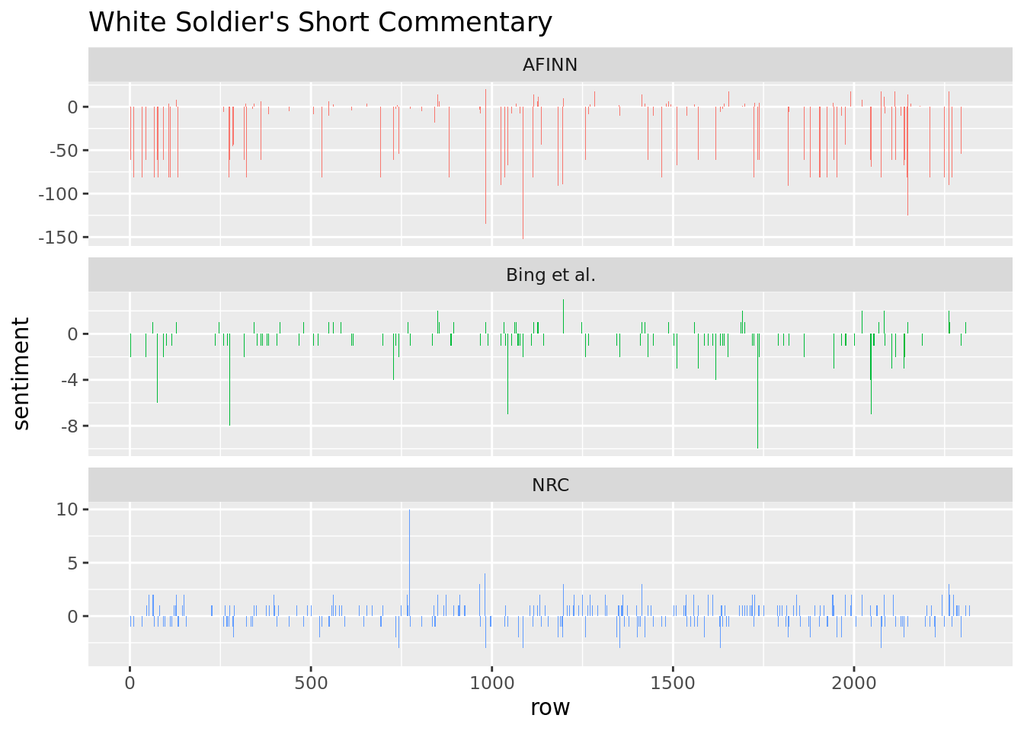

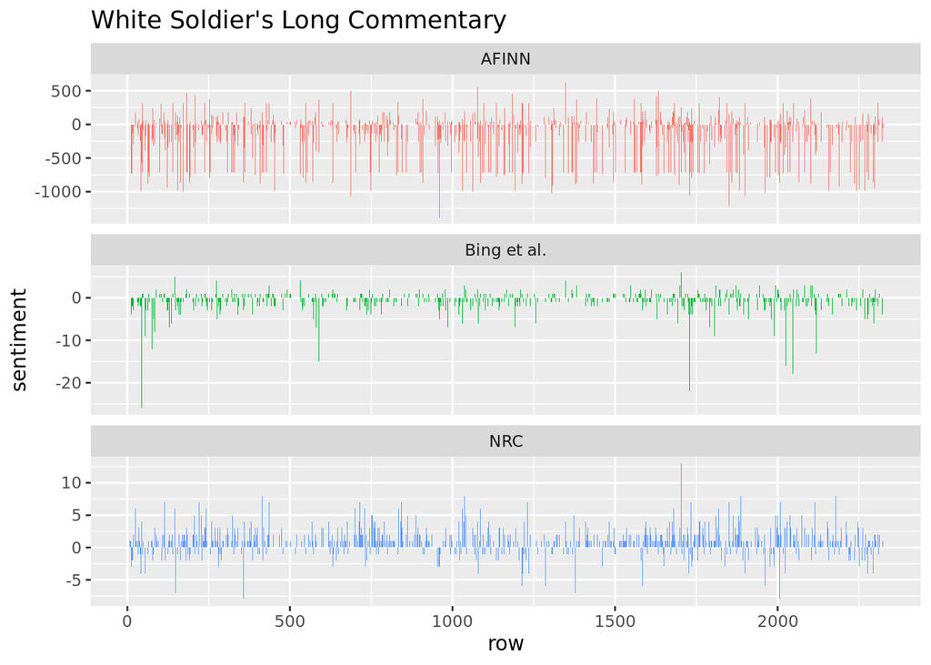

## Word Plots

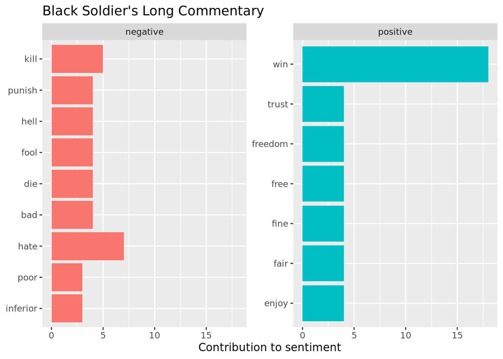

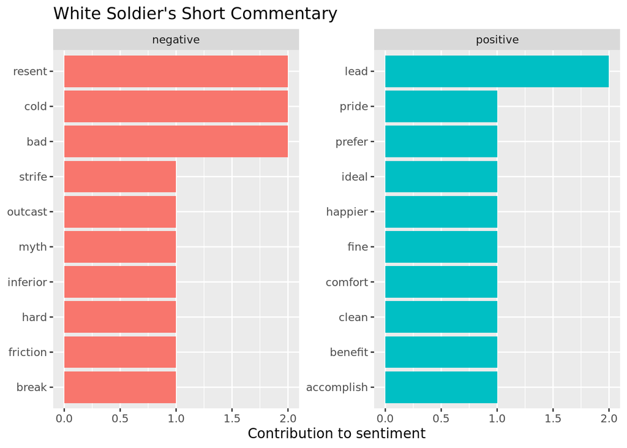

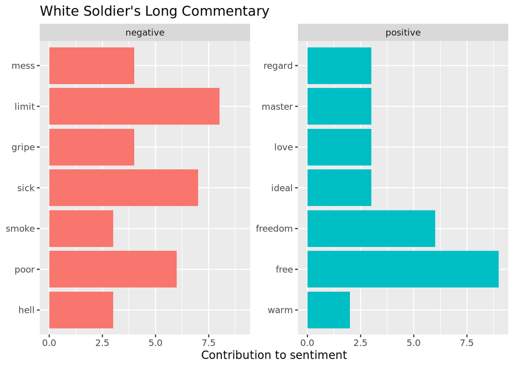

## Word Clouds

We have created word clouds for each group's length of responses. These plots show the most popular 50 words.

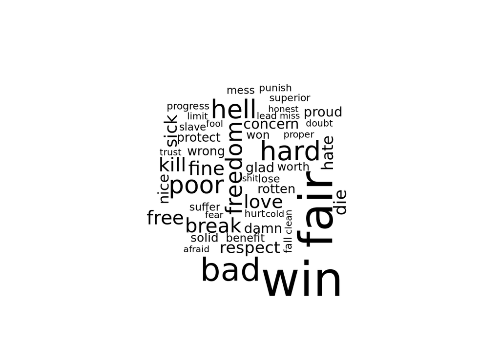

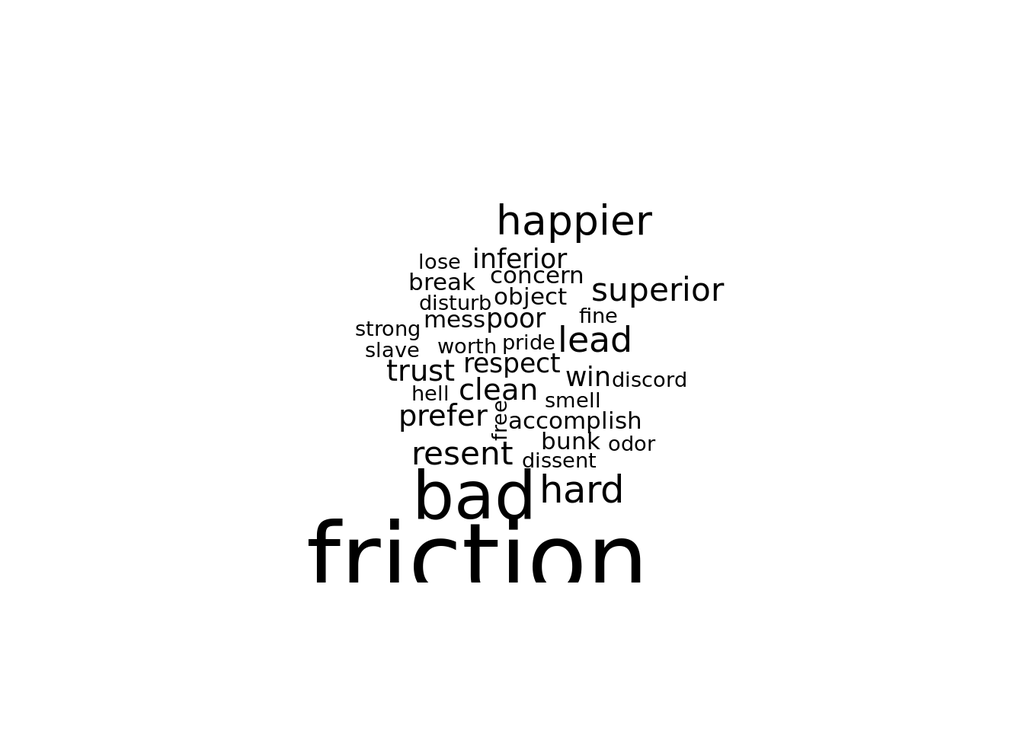

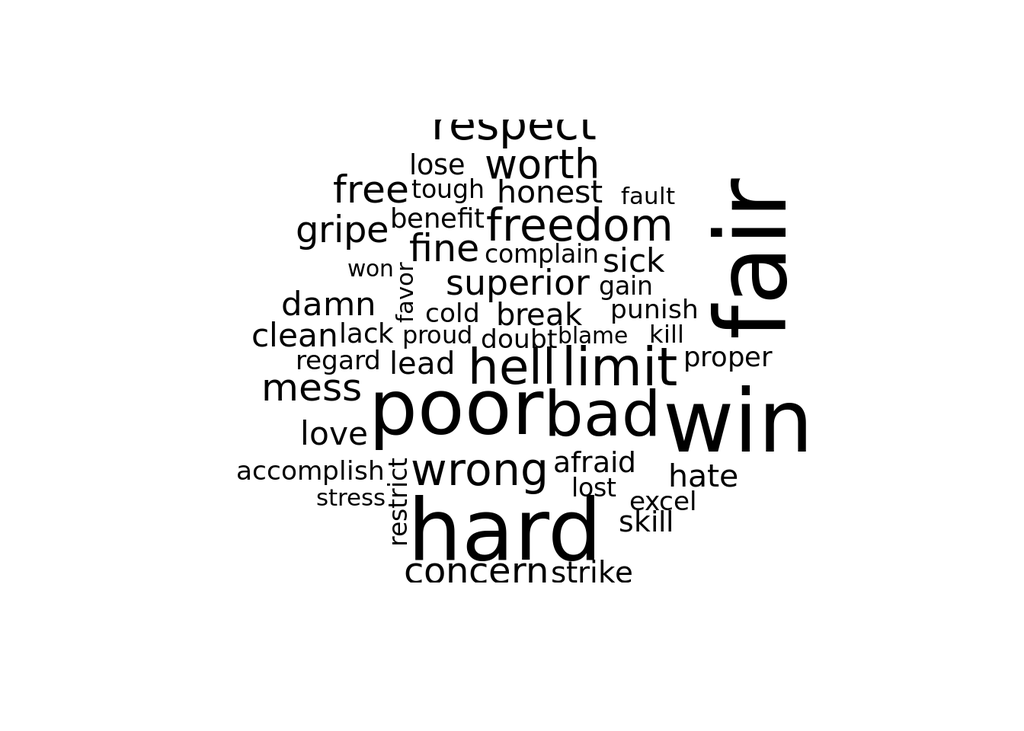